# n20 - Multiple Facility Network Location Problem

*Transport Analytics Training Series - Last Revision: October 2022*

## Multiple Facility Location Problems

```python
import numpy as np
import matplotlib
import matplotlib.pyplot as plt
import seaborn as sns; sns.set()
from sklearn.datasets import make_blobs

%matplotlib inline

plot_size   = 30
plot_width  = 19
plot_height = 17

params = {'legend.fontsize': 'large',
          'figure.figsize': (plot_width,plot_height),
          'axes.labelsize': plot_size,
          'axes.titlesize': plot_size,
          'xtick.labelsize': plot_size*0.75,
          'ytick.labelsize': plot_size*0.75,
          'axes.titlepad': 25}
plt.rcParams.update(params)
```

```python
num_customer = 40
num_facility = 5
```

```python
center_box = (100, 200)

cust_coord, _  = make_blobs(n_samples=num_customer,
                            centers=2,
                            cluster_std=20,
                            center_box=center_box,
                            random_state = 2)

facil_coord, _ = make_blobs(n_samples=num_facility,
                            centers=1,
                            cluster_std=30,
                            center_box=center_box,
                            random_state = 50)
```

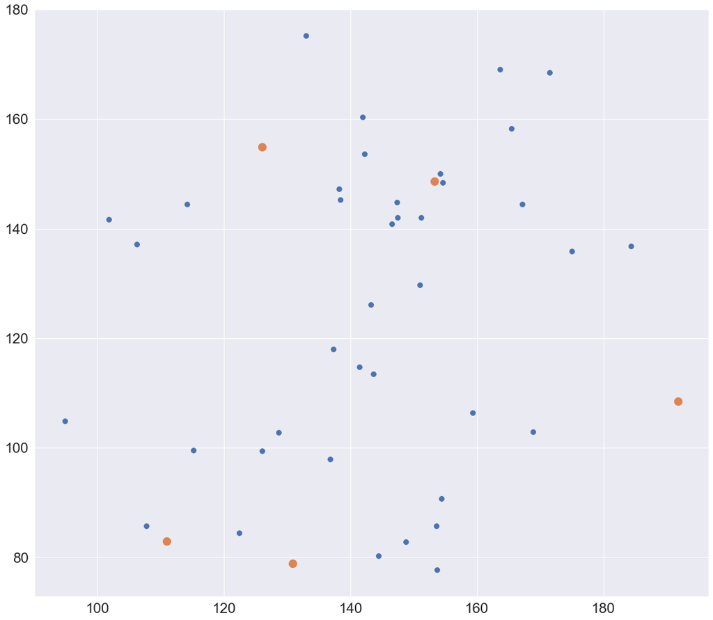

```python
plt.scatter(cust_coord[:, 0],
            cust_coord[:, 1],
            s=plot_size*2,
            cmap='viridis');

plt.scatter(facil_coord[:, 0],
            facil_coord[:, 1],
            s=plot_size*5,
            cmap='viridis');
```

```python
from pulp import *

prob = LpProblem('prob', LpMinimize)
```

```python
from scipy.spatial import distance

dist_matrix = distance.cdist(cust_coord, facil_coord, 'euclidean')
```

```python
S = [('S'+str(i+1)) for i in range(num_facility)]
D = [('C'+str(i+1)) for i in range(num_customer)]
```

```python
n = 2
```

We are using the above parameter variable to set the number of facilities to be opened.

```python
d = {customer:{facility:dist_matrix[i][j] for j,facility in enumerate(S)} for i,customer in enumerate(D)}
```

```python
x = LpVariable.dicts('x', (D,S), lowBound = 0, upBound = 1, cat = LpInteger)
y = LpVariable.dicts('y', S, lowBound = 0, upBound = 1, cat = LpInteger)
```

```python
prob += lpSum([lpSum([x[i][j]*d[i][j] for j in S]) for i in D])
```

```python
for i in D:
    prob += lpSum([x[i][j] for j in S]) == 1

prob += lpSum([y[j] for j in S]) == n

for i in D:
    for j in S:
        prob += x[i][j] <= y[j]
```

Note that in the 2nd constrained we use n to define the number of facilities to be opened.

```python
status = prob.solve()

print(f'STATUS\n{LpStatus[status]}\n')
```

[output not shown]

```python
chosen_facil = []
for j,facility in enumerate(S):
    if y[facility].varValue == 1:
        chosen_facil.append(j)
        print(f'We will be opening facility {facility}')

chosen_facil
```

```
We will be opening facility S2
We will be opening facility S4
```

```
[1, 3]
```

## Summary

[output not shown]

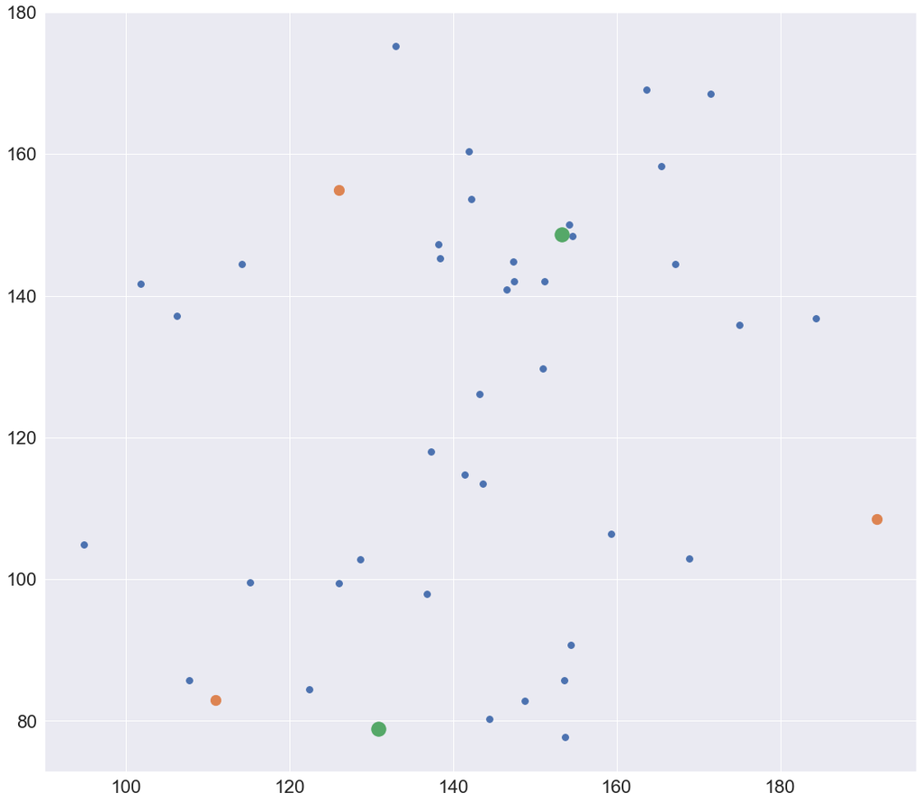

```python
plt.scatter(cust_coord[:, 0],
            cust_coord[:, 1],
            s=plot_size*2,
            cmap='viridis',
            zorder = 10000);

plt.scatter(facil_coord[:, 0],
            facil_coord[:, 1],
            s=plot_size*5,
            cmap='viridis');

plt.scatter(facil_coord[chosen_facil, 0],
            facil_coord[chosen_facil, 1],
            s=plot_size*10,
            cmap='viridis',
            zorder=99999)
```

The above graph plots correctly the facilities to be opened, but how do we know which one serves any customer?

```python
vect_orig = []
vect_dest = []
u = v = np.zeros((len(vect_orig),len(vect_orig)))

for j,facility in enumerate(S):
    for i,customer in enumerate(D):
        if x[customer][facility].varValue == 1:
            vect_orig.append(facil_coord[j])
            vect_dest.append(cust_coord[i])

vect_orig = np.array(vect_orig)
vect_dest = np.array(vect_dest)
```

In the above code we are iterating through our sets of facilities and customers.

Wherever we find a pair that is connected, we will append the origin and destination coordinates of a link between them to `vect_orig` and `vect_dest`, respectively.

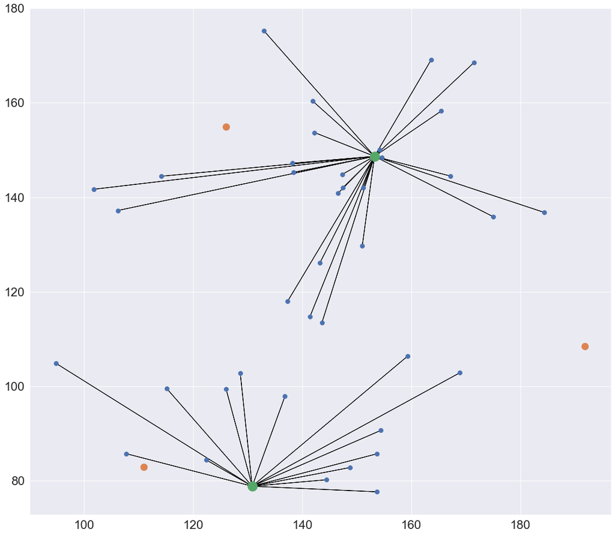

```python
plt.scatter(cust_coord[:, 0],
            cust_coord[:, 1],
            s=plot_size*2,
            cmap='viridis',
            zorder = 10000);

plt.scatter(facil_coord[:, 0],
            facil_coord[:, 1],
            s=plot_size*5,
            cmap='viridis');

plt.scatter(facil_coord[chosen_facil, 0],
            facil_coord[chosen_facil, 1],
            s=plot_size*10,
            cmap='viridis',
            zorder=99999)

for i in range(len(vect_orig)):
    plt.arrow(vect_orig[i][0],
              vect_orig[i][1],
              vect_dest[i][0]-vect_orig[i][0],
              vect_dest[i][1]-vect_orig[i][1],
              color='black')
```

We have now replotted the graph, but with the addition of arrows between facilities and the customers that they serve.

The eagled-eyed among you might have notices that we are now also using the `zorder` parameter, which allows us to define the order with which the elements of the graph are served.